# Topic 6: Topic Analysis

```r
library(here)
library(pdftools)
library(quanteda)
library(tm)
library(topicmodels)
library(ldatuning)
library(tidyverse)
library(tidytext)
library(reshape2)
```

Load the data

```r
##Topic 6 .Rmd here:https://raw.githubusercontent.com/MaRo406/EDS_231-text-sentiment/main/topic_6.Rmd
#grab data here:
comments_df<-read_csv("https://raw.githubusercontent.com/MaRo406/EDS_231-text-sentiment/main/dat/comments_df.csv")
#comments_df <- read_csv(here("dat", "comments_df.csv")) #if reading from local
```

Now we’ll build and clean the corpus

```r
epa_corp <- corpus(x = comments_df, text_field = "text")
epa_corp.stats <- summary(epa_corp)
head(epa_corp.stats, n = 25)
```

```
##      Text Types Tokens Sentences
## 1   text1  1196   3973       178
## 2   text2   830   2509       111
## 3   text3   279    571        31
## 4   text4  1745   6904       251
## 5   text5   581   1534        49
## 6   text6   469   1187        53
## 7   text7   424    903        38
## 8   text8  3622  22270       655
## 9   text9   373    717        25
## 10 text10   404    971        42
## 11 text11   710   2190        77
## 12 text12   636   1896        82
## 13 text13   146    206         3
## 14 text14  1124   3197        86
```

[output cut: 37 more lines]

```r
toks <- tokens(epa_corp, remove_punct = TRUE, remove_numbers = TRUE)
#I added some project-specific stop words here
add_stops <- c(stopwords("en"),"environmental", "justice", "ej", "epa", "public", "comment")
toks1 <- tokens_select(toks, pattern = add_stops, selection = "remove")
```

And now convert to a document-feature matrix

```r
dfm_comm<- dfm(toks1, tolower = TRUE)
dfm <- dfm_wordstem(dfm_comm)
dfm <- dfm_trim(dfm, min_docfreq = 2) #remove terms only appearing in one doc (min_termfreq = 10)

print(head(dfm))
```

```
## Document-feature matrix of: 6 documents, 2,781 features (82.75% sparse) and 1 docvar.
##        features
## docs    charl lee deputi associ assist administr usepa offic 2201-a
##   text1     1   2      1      1      6         6     1     7      1
##   text2     1   1      1      4      3         1     0     5      0
##   text3     0   0      0      0      1         0     0     2      0
##   text4     0   0      0      0      1         9     0     1      0
##   text5     4   5      1      1      1         1     0     1      1
##   text6     1   1      1      3      1         3     0     4      0
##        features
## docs    pennsylvania
##   text1            1
##   text2            0
##   text3            0
##   text4            0
##   text5            1
##   text6            0
## [ reached max_nfeat ... 2,771 more features ]
```

```r
#remove rows (docs) with all zeros
sel_idx <- slam::row_sums(dfm) > 0
dfm <- dfm[sel_idx, ]
#comments_df <- dfm[sel_idx, ]
```

```r
#
result <- FindTopicsNumber(
  dfm,
  topics = seq(from = 2, to = 20, by = 1),
  metrics = c("CaoJuan2009",  "Deveaud2014"),
  method = "Gibbs",
  control = list(seed = 77),
  verbose = TRUE
)
```

```
## fit models... done.
## calculate metrics:
##   CaoJuan2009... done.
##   Deveaud2014... done.
```

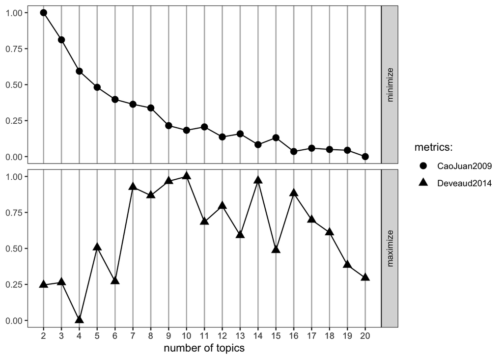

```r
FindTopicsNumber_plot(result)
```

### Assignment:

Either:

1. continue on with the analysis we started:

### Model 1 (k = 10)

```r
k <- 10

topicModel_k10 <- LDA(dfm, k,
                     method = "Gibbs",
                     control = list(iter = 500, verbose = 25))
```

```
## K = 10; V = 2781; M = 77
## Sampling 500 iterations!
## Iteration 25 ...
## Iteration 50 ...
## Iteration 75 ...
## Iteration 100 ...
## Iteration 125 ...
## Iteration 150 ...
## Iteration 175 ...
## Iteration 200 ...
## Iteration 225 ...
## Iteration 250 ...
## Iteration 275 ...
## Iteration 300 ...
## Iteration 325 ...
## Iteration 350 ...
## Iteration 375 ...
## Iteration 400 ...
## Iteration 425 ...
## Iteration 450 ...
## Iteration 475 ...
## Iteration 500 ...
## Gibbs sampling completed!
```

```r
tmResult <- posterior(topicModel_k10)
terms(topicModel_k10, 10)
```

```
##       Topic 1     Topic 2     Topic 3     Topic 4     Topic 5   Topic 6
##  [1,] "state"     "communiti" "communiti" "program"   "prison"  "water"
##  [2,] "permit"    "pollut"    "enforc"    "state"     "peopl"   "can"
##  [3,] "consid"    "comment"   "includ"    "feder"     "project" "site"
##  [4,] "use"       "health"    "monitor"   "recommend" "citi"    "econom"
##  [5,] "air"       "can"       "action"    "will"      "park"    "juli"
##  [6,] "grant"     "protect"   "complianc" "polici"    "right"   "industri"
##  [7,] "framework" "new"       "requir"    "epa"       "health"  "energi"
##  [8,] "opportun"  "impact"    "data"      "specif"    "law"     "infrastructur"
##  [9,] "carolina"  "reduc"     "report"    "regul"     "green"   "will"
## [10,] "train"     "polici"    "permit"    "may"       "see"     "fund"
##       Topic 7   Topic 8     Topic 9    Topic 10
##  [1,] "agenc"   "framework" "state"    "communiti"
##  [2,] "right"   "communiti" "rule"     "plan"
##  [3,] "titl"    "draft"     "impact"   "strategi"
##  [4,] "vi"      "effort"    "popul"    "use"
##  [5,] "civil"   "develop"   "also"     "local"
##  [6,] "issu"    "comment"   "air"      "comment"
##  [7,] "act"     "action"    "asthma"   "govern"
##  [8,] "work"    "agenc"     "ejscreen" "particip"
##  [9,] "address" "agenda"    "guidanc"  "action"
## [10,] "feder"   "goal"      "agenc"    "agenda"
```

```r
theta <- tmResult$topics
beta <- tmResult$terms # probability of each term in each topic
vocab <- (colnames(beta))
```

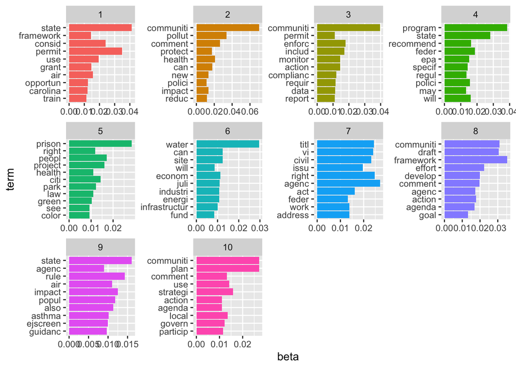

```r
comment_topics <- tidy(topicModel_k10, matrix = "beta")

top_terms <- comment_topics %>%
  group_by(topic) %>%
  top_n(10, beta) %>%
  ungroup() %>%
  arrange(topic, -beta)

top_terms %>%
  mutate(term = reorder(term, beta)) %>%
  ggplot(aes(term, beta, fill = factor(topic))) +
  geom_col(show.legend = FALSE) +
  facet_wrap(~ topic, scales = "free") +
  coord_flip()
```

```r
top5termsPerTopic <- terms(topicModel_k10, 5)
topicNames_k10 <- apply(top5termsPerTopic, 2, paste, collapse=" ")
```

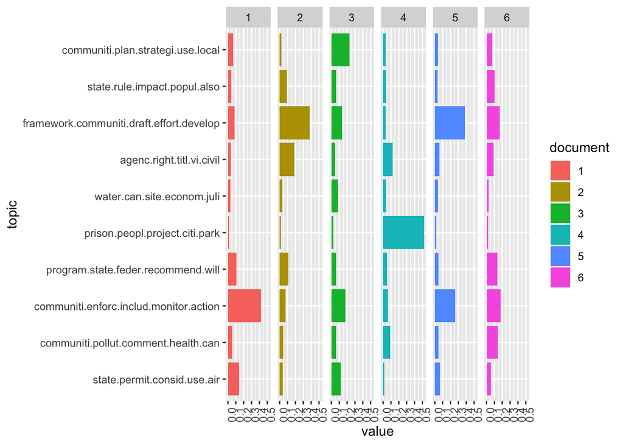

```r
exampleIds <- c(1, 2, 3, 4, 5, 6)
N <- length(exampleIds)

#lapply(epa_corp[exampleIds], as.character) #uncomment to view example text
# get topic proportions form example documents
topicProportions <- theta[exampleIds,]
colnames(topicProportions) <- topicNames_k10
vizDataFrame <- melt(cbind(data.frame(topicProportions), document=factor(1:N)), variable.name = "topic", id.vars = "document")
ggplot(data = vizDataFrame, aes(topic, value, fill = document), ylab = "proportion") +
  geom_bar(stat="identity") +
  theme(axis.text.x = element_text(angle = 90, hjust = 1)) +
  coord_flip() +
  facet_wrap(~ document, ncol = N)
```

```r
library(LDAvis)
library("tsne")
```

```r
svd_tsne <- function(x) tsne(svd(x)$u)
json <- createJSON(
  phi = tmResult$terms,
  theta = tmResult$topics,
  doc.length = rowSums(dfm),
  vocab = colnames(dfm),
  term.frequency = colSums(dfm),
  mds.method = svd_tsne,
  plot.opts = list(xlab="", ylab="")
)
```

```
## sigma summary: Min. : 33554432 |1st Qu. : 33554432 |Median : 33554432 |Mean : 33554432 |3rd Qu. : 33554432 |Max. : 33554432 |
```

```
## Epoch: Iteration #100 error is: 14.8113217018707
```

```
## Epoch: Iteration #200 error is: 0.825518753829916
```

```
## Epoch: Iteration #300 error is: 0.438595668278557
```

```
## Epoch: Iteration #400 error is: 0.343063729870272
```

```
## Epoch: Iteration #500 error is: 0.303690451702849
```

```
## Epoch: Iteration #600 error is: 0.284415341040395
```

```
## Epoch: Iteration #700 error is: 0.275017781008682
```

```
## Epoch: Iteration #800 error is: 0.269564316107022
```

```
## Epoch: Iteration #900 error is: 0.264416152764953
```

```
## Epoch: Iteration #1000 error is: 0.259870459891395
```

```r
serVis(json)
```

### Model 2 (k = 5)

```r
k <- 5

topicModel_k5 <- LDA(dfm, k,
                     method = "Gibbs",
                     control = list(iter = 500, verbose = 25))
```

```
## K = 5; V = 2781; M = 77
## Sampling 500 iterations!
## Iteration 25 ...
## Iteration 50 ...
## Iteration 75 ...
## Iteration 100 ...
## Iteration 125 ...
## Iteration 150 ...
## Iteration 175 ...
## Iteration 200 ...
## Iteration 225 ...
## Iteration 250 ...
## Iteration 275 ...
## Iteration 300 ...
## Iteration 325 ...
## Iteration 350 ...
## Iteration 375 ...
## Iteration 400 ...
## Iteration 425 ...
## Iteration 450 ...
## Iteration 475 ...
## Iteration 500 ...
## Gibbs sampling completed!
```

```r
tmResult <- posterior(topicModel_k5)
terms(topicModel_k5, 10)
```

```
##       Topic 1     Topic 2     Topic 3   Topic 4     Topic 5
##  [1,] "state"     "communiti" "right"   "communiti" "state"
##  [2,] "impact"    "prison"    "health"  "enforc"    "framework"
##  [3,] "pollut"    "local"     "civil"   "includ"    "draft"
##  [4,] "popul"     "water"     "vi"      "comment"   "permit"
##  [5,] "also"      "strategi"  "titl"    "action"    "feder"
##  [6,] "provid"    "work"      "project" "plan"      "effort"
##  [7,] "health"    "econom"    "peopl"   "air"       "agenc"
##  [8,] "rule"      "plan"      "agenc"   "monitor"   "develop"
##  [9,] "communiti" "agenda"    "issu"    "requir"    "program"
## [10,] "air"       "can"       "includ"  "need"      "comment"
```

```r
theta <- tmResult$topics
beta <- tmResult$terms # probability of each term in each topic
vocab <- (colnames(beta))
```

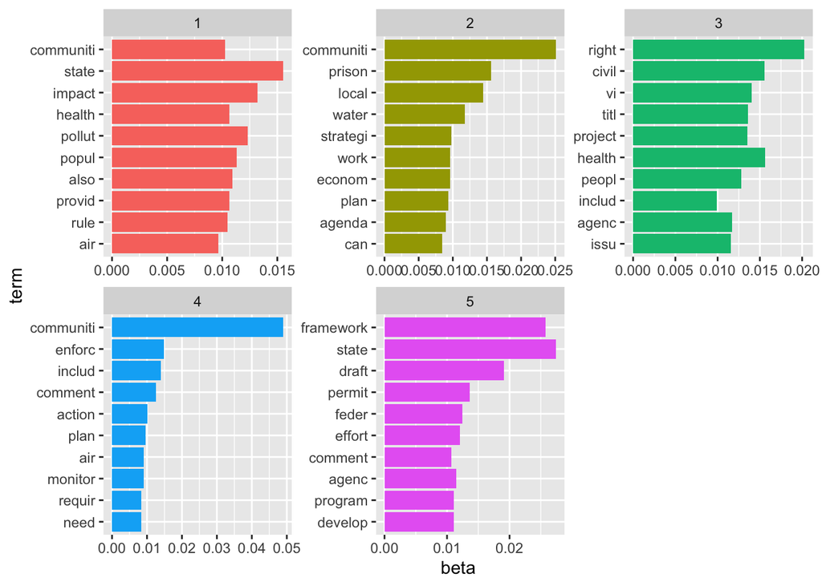

```r
comment_topics <- tidy(topicModel_k5, matrix = "beta")

top_terms <- comment_topics %>%
  group_by(topic) %>%
  top_n(10, beta) %>%
  ungroup() %>%
  arrange(topic, -beta)

top_terms %>%
  mutate(term = reorder(term, beta)) %>%
  ggplot(aes(term, beta, fill = factor(topic))) +
  geom_col(show.legend = FALSE) +
  facet_wrap(~ topic, scales = "free") +
  coord_flip()
```

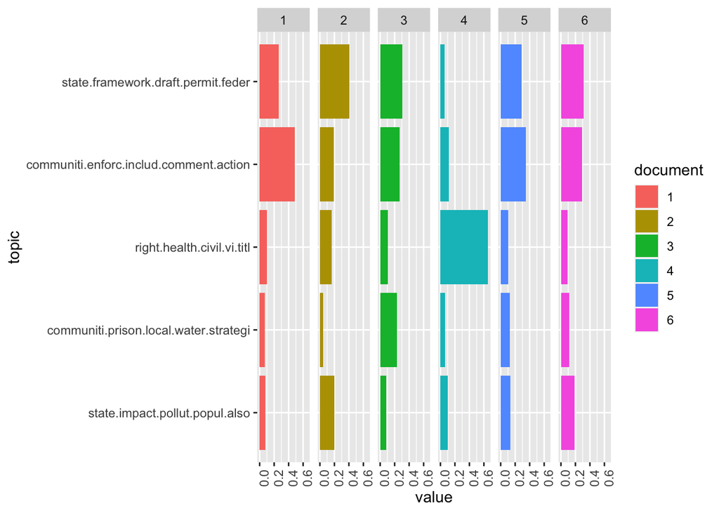

```r
top5termsPerTopic <- terms(topicModel_k5, 5)
topicNames_k5 <- apply(top5termsPerTopic, 2, paste, collapse=" ")

exampleIds <- c(1, 2, 3, 4, 5, 6)
N <- length(exampleIds)

#lapply(epa_corp[exampleIds], as.character) #uncomment to view example text
# get topic proportions form example documents
topicProportions <- theta[exampleIds,]
colnames(topicProportions) <- topicNames_k5
vizDataFrame <- melt(cbind(data.frame(topicProportions), document=factor(1:N)), variable.name = "topic", id.vars = "document")
ggplot(data = vizDataFrame, aes(topic, value, fill = document), ylab = "proportion") +
  geom_bar(stat="identity") +
  theme(axis.text.x = element_text(angle = 90, hjust = 1)) +
  coord_flip() +
  facet_wrap(~ document, ncol = N)
```

```r
library(LDAvis)
library("tsne")
svd_tsne <- function(x) tsne(svd(x)$u)
json <- createJSON(
  phi = tmResult$terms,
  theta = tmResult$topics,
  doc.length = rowSums(dfm),
  vocab = colnames(dfm),
  term.frequency = colSums(dfm),
  mds.method = svd_tsne,
  plot.opts = list(xlab="", ylab="")
)
```

```
## sigma summary: Min. : 33554432 |1st Qu. : 33554432 |Median : 33554432 |Mean : 33554432 |3rd Qu. : 33554432 |Max. : 33554432 |
```

```
## Epoch: Iteration #100 error is: 9.96334784274005
```

```
## Epoch: Iteration #200 error is: 0.122995167552164
```

```
## Epoch: Iteration #300 error is: 0.110467929560893
```

```
## Epoch: Iteration #400 error is: 0.110463634834943
```

```
## Epoch: Iteration #500 error is: 0.110463537672032
```

```
## Epoch: Iteration #600 error is: 0.110463537113159
```

```
## Epoch: Iteration #700 error is: 0.110463536971401
```

```
## Epoch: Iteration #800 error is: 0.110463536760485
```

```
## Epoch: Iteration #900 error is: 0.110463536484037
```

```
## Epoch: Iteration #1000 error is: 0.110463536143665
```

```r
serVis(json)
```

### Best k-value

Based on the plot we made in class from Deveaud2014 method, it looks like 10 number of topics maximizes the metric. We know there are 9 priority areas from the EPA so it makes sense that there may be an extra topic that catches another topic from the pdfs.

OR

2. use the data you plan to use for your final project:

Prepare the data so that it can be analyzed in the topicmodels package

Run three more models and select the overall best value for k (the number of topics) - include some justification for your selection: theory, FindTopicsNumber() optimization metrics, interpretability, LDAvis